# Gene Ontology Enrichment/Overrepresentation Analysis on Pulmonary TB Infected Tissues in Mice

```r
# gene id and titles are stored in the gene_assignment column in GPL16570_lung.  make a function to grab the
# second and third items from gene_assignment
parseGI <- function(gene_assignment) {
    # use regex to find the first two items. I hate regex...
    str_ful <- str_match(gene_assignment, "// (\\w+) // (.+?) //")
    gene_id <- str_ful[2]
    gene_title <- str_ful[3]
    # return the data as list for subsequent cbind actions
    return(list(Gene_id = gene_id, Gene_title = gene_title))
}

# parsing GO terms biological process is chosen
parsGO <- function(probe, ontology = "GO_biological_process") {
    go_segment <- strsplit(GPL16570_lung[probe, "GO_biological_process"], "///")[[1]]
    go_id <- trimws(unlist(lapply(go_segment, function(x) strsplit(x, "//")[[1]][2])))
    go_description <- trimws(unlist(lapply(go_segment, function(x) strsplit(x, "//")[[1]][3])))
    go_source <- trimws(unlist(lapply(go_segment, function(x) strsplit(x, "//")[[1]][4])))

    # in case of probe without id (a.k.a. errors in data wrangling)
    if (length(go_id) > 0) {
        go_tab <- cbind(Probe_id = probe, Id = go_id, Description = go_description, Source = go_source)
        rownames(go_tab) <- rep(probe, nrow(go_tab))
        return(go_tab)
        return()  # return nothing if go_id is empty/NA (perhaps stopping the process with a warning also works)
    }
}

# prepare AGO and GO data <NOTE this in inefficient. Try break down GO by Ex_group, and then define another
# function later to rbind them.>
prepGO <- function(degs) {
    # match information between Array GO terms from DEG result and GPL16750_lung.
    AGO <- cbind(Gene_Symbol = GPL16570_lung[degs$Probe, c("probeset_id", "Gene_id", "Gene_title")], degs[, c("logFC",
        "p.value", "adj.P.Val")])
    colnames(AGO) <- c("Probe_id", "Gene_id", "Gene_title", "logFC", "P.Val", "adj.P.Val")

    # parse all GO terms on Biological Process column from GPL16570.
    GO <- c()

    for (probe in rownames(AGO)) {
        GO <- rbind(GO, parsGO(probe))
    }

    # drop the rows with only na.
    GO <- as.data.frame(GO[rowSums(is.na(GO)) != ncol(GO), ])
    GO <- na.omit(GO)

    # match AGO and GO, as DEGs without GO term is of little significant to our purpose.
    AGO <- AGO[which(AGO$Probe_id %in% GO$Probe_id), ]
    # AGO <- AGO %>% mutate(has_GO = ifelse(Probe_id %in% GO$Probe_id, TRUE, FALSE))

    # combine the result into a list for subsequent enrichment analysis.
    result <- list(AGO, GO)
    names(result) <- c("AGO", "GO")

    return(result)
}
```

```r
# modify GPL16570_lung in place
GPL16570_lung <- GPL16570_lung %>%
    mutate(Gene_id = map_chr(gene_assignment, ~parseGI(.x)$Gene_id), Gene_title = map_chr(gene_assignment, ~parseGI(.x)$Gene_title))
```

This following section may be quite slow as we have many samples, probes, and GO terms. I should look into more efficient way to process the GO data in the future. As for now, please be patient with my insufficient brain.

[output not shown]

```r
# specify the result from the correct group of deg.
degs <- deg_ui_ac$deg_results

# parse gene IDs and GO terms.
Genego_ui_ac <- prepGO(degs)
head(Genego_ui_ac$AGO)
head(Genego_ui_ac$GO)
##          Probe_id  Gene_id
## 17218765 17218765   Kifap3
## 17332851 17332851   Gtf2h5
## 17411174 17411174    Gipc2
## 17447737 17447737    Rab28
## 17289304 17289304 Col4a3bp
## 17453205 17453205     Sbds
##                                                                Gene_title
## 17218765                                     kinesin-associated protein 3
## 17332851                  general transcription factor IIH, polypeptide 5
## 17411174                      GIPC PDZ domain containing family, member 2
## 17447737                                RAB28, member RAS oncogene family
## 17289304 collagen, type IV, alpha 3 (Goodpasture antigen) binding protein
## 17453205                Shwachman-Bodian-Diamond syndrome homolog (human)
##                logFC        P.Val    adj.P.Val
## 17218765  0.20224742 1.360091e-12 1.309057e-09
## 17332851  0.26379304 1.360091e-12 1.309057e-09
## 17411174  0.14519325 1.360091e-12 1.309057e-09
## 17447737  0.22758392 1.360091e-12 1.309057e-09
## 17289304 -0.37196119 1.469384e-12 1.309057e-09
## 17453205 -0.01942914 1.469384e-12 1.309057e-09
##             Probe_id         Id
## X17218765   17218765 GO:0007017
## X17218765.1 17218765 GO:0007266
## X17218765.2 17218765 GO:0008104
## X17218765.3 17218765 GO:0008285
## X17218765.4 17218765 GO:0046587
## X17218765.5 17218765 GO:0050790
##                                                             Description
## X17218765                                     microtubule-based process
## X17218765.1                             Rho protein signal transduction
## X17218765.2                                        protein localization
## X17218765.3                   negative regulation of cell proliferation
## X17218765.4 positive regulation of calcium-dependent cell-cell adhesion
## X17218765.5                            regulation of catalytic activity
##                                         Source
## X17218765   inferred from physical interaction
## X17218765.1         traceable author statement
## X17218765.2     inferred from mutant phenotype
## X17218765.3     inferred from mutant phenotype
## X17218765.4     inferred from mutant phenotype
## X17218765.5         traceable author statement
```

```r
# specify the result from the correct group of deg.
degs <- deg_ui_cc$deg_results

# parse gene IDs and GO terms.
Genego_ui_cc <- prepGO(degs)
head(Genego_ui_cc$AGO)
head(Genego_ui_cc$GO)
##          Probe_id Gene_id                                       Gene_title
## 17212442 17212442   Gulp1 GULP, engulfment adaptor PTB domain containing 1
## 17213369 17213369  Nbeal1                              neurobeachin like 1
## 17215309 17215309  Inpp5d           inositol polyphosphate-5-phosphatase D
## 17217399 17217399  Chi3l1                               chitinase 3-like 1
## 17218261 17218261    Ncf2                    neutrophil cytosolic factor 2
## 17218765 17218765  Kifap3                     kinesin-associated protein 3
##                logFC        P.Val    adj.P.Val
## 17212442  0.33550636 5.557753e-08 3.491952e-06
## 17213369  0.14203227 5.557753e-08 3.491952e-06
## 17215309  0.33879909 5.557753e-08 3.491952e-06
## 17217399  0.15646243 5.557753e-08 3.491952e-06
## 17218261 -0.23698871 5.557753e-08 3.491952e-06
## 17218765  0.07680442 5.557753e-08 3.491952e-06
##             Probe_id         Id              Description
## X17212442   17212442 GO:0006810                transport
## X17212442.1 17212442 GO:0006869          lipid transport
## X17212442.2 17212442 GO:0006909             phagocytosis
## X17212442.3 17212442 GO:0006911 phagocytosis, engulfment
## X17212442.4 17212442 GO:0006915        apoptotic process
## X17212442.5 17212442 GO:0006810                transport
##                                          Source
## X17212442   inferred from electronic annotation
## X17212442.1 inferred from electronic annotation
## X17212442.2 inferred from electronic annotation
## X17212442.3                        not recorded
## X17212442.4 inferred from electronic annotation
## X17212442.5 inferred from electronic annotation
```

```r
# specify the result from the correct group of deg.
degs <- deg_ui_pr$deg_results

# parse gene IDs and GO terms.
Genego_ui_pr <- prepGO(degs)
head(Genego_ui_pr$AGO)
head(Genego_ui_pr$GO)
##          Probe_id Gene_id
## 17300349 17300349  Bcl2l2
## 17225929 17225929     Pam
## 17230735 17230735   Mosc2
## 17233408 17233408    Gcc2
## 17234317 17234317 Specc1l
## 17236604 17236604    Ntn4
##                                                                   Gene_title
## 17300349                                                         BCL2-like 2
## 17225929                       peptidylglycine alpha-amidating monooxygenase
## 17230735                      MOCO sulphurase C-terminal domain containing 2
## 17233408                            GRIP and coiled-coil domain containing 2
## 17234317 sperm antigen with calponin homology and coiled-coil domains 1-like
## 17236604                                                            netrin 4
##               logFC        P.Val    adj.P.Val
## 17300349 0.34374754 2.064315e-11 3.248298e-09
## 17225929 0.13654667 2.065399e-11 3.248298e-09
## 17230735 0.08530978 2.065399e-11 3.248298e-09
## 17233408 0.30454773 2.065399e-11 3.248298e-09
## 17234317 0.02816917 2.065399e-11 3.248298e-09
## 17236604 0.53832490 2.065399e-11 3.248298e-09
##             Probe_id         Id                              Description
## X17300349   17300349 GO:0006915                        apoptotic process
## X17300349.1 17300349 GO:0006915                        apoptotic process
## X17300349.2 17300349 GO:0006915                        apoptotic process
## X17300349.3 17300349 GO:0042981          regulation of apoptotic process
## X17300349.4 17300349 GO:0043066 negative regulation of apoptotic process
## X17300349.5 17300349 GO:0060011               Sertoli cell proliferation
##                                                    Source
## X17300349                      inferred from direct assay
## X17300349.1                                  not recorded
## X17300349.2 inferred from reviewed computational analysis
## X17300349.3 inferred from reviewed computational analysis
## X17300349.4                                  not recorded
## X17300349.5             inferred from genetic interaction
```

```r
# specify the result from the correct group of deg.
degs <- deg_ac_cc$deg_results

# parse gene IDs and GO terms.
Genego_ac_cc <- prepGO(degs)
head(Genego_ac_cc$AGO)
head(Genego_ac_cc$GO)
##          Probe_id       Gene_id                         Gene_title       logFC
## 17540027 17540027       Gm15453               predicted gene 15453  0.22305830
## 17533093 17533093       Slc38a5 solute carrier family 38, member 5  0.32705546
## 17294086 17294086         Adcy2                adenylate cyclase 2  0.16146140
## 17534746 17534746         Cxx1c       CAAX box 1 homolog C (human) -0.09021549
## 17465971 17465971 D630045J12Rik         RIKEN cDNA D630045J12 gene -0.01820726
## 17268633 17268633         Rpl23              ribosomal protein L23 -0.11982611
##                 P.Val   adj.P.Val
## 17540027 3.487887e-07 0.003447869
## 17533093 8.196895e-07 0.003447869
## 17294086 1.083488e-06 0.003447869
## 17534746 1.083488e-06 0.003447869
## 17465971 1.161238e-06 0.003447869
## 17268633 1.333150e-06 0.003447869
##             Probe_id         Id
## X17540027   17540027 GO:0006412
## X17540027.1 17540027 GO:0006417
## X17540027.2 17540027 GO:0006950
## X17540027.3 17540027 GO:0009409
## X17540027.4 17540027 GO:0035196
## X17540027.5 17540027 GO:0045727
##                                                          Description
## X17540027                                                translation
## X17540027.1                                regulation of translation
## X17540027.2                                       response to stress
## X17540027.3                                         response to cold
## X17540027.4 production of miRNAs involved in gene silencing by miRNA
## X17540027.5                       positive regulation of translation
##                                          Source
## X17540027            inferred from direct assay
## X17540027.1          inferred from direct assay
## X17540027.2 inferred from electronic annotation
## X17540027.3          inferred from direct assay
## X17540027.4          inferred from direct assay
## X17540027.5                        not recorded
```

```r
# specify the result from the correct group of deg.
degs <- deg_ac_pr$deg_results

# parse gene IDs and GO terms.
Genego_ac_pr <- prepGO(degs)
head(Genego_ac_pr$AGO)
head(Genego_ac_pr$GO)
##          Probe_id Gene_id                                      Gene_title
## 17326075 17326075  Retnlg                             resistin like gamma
## 17503942 17503942     Mt1                               metallothionein 1
## 17522369 17522369     Ngp                    neutrophilic granule protein
## 17407363 17407363  S100a9 S100 calcium binding protein A9 (calgranulin B)
## 17399823 17399823  S100a8 S100 calcium binding protein A8 (calgranulin A)
## 17291881 17291881   F13a1             coagulation factor XIII, A1 subunit
##                logFC        P.Val    adj.P.Val
## 17326075  0.14150012 2.014533e-15 3.913795e-11
## 17503942 -0.12724637 2.768020e-15 3.913795e-11
## 17522369 -0.05988347 3.141811e-15 3.913795e-11
## 17407363  0.07696381 3.797485e-15 3.913795e-11
## 17399823  0.10931033 7.114540e-15 3.913795e-11
## 17291881 -0.01420111 1.409219e-14 5.826417e-11
##             Probe_id         Id                    Description
## X17326075   17326075 GO:0008150             biological_process
## X17326075.1 17326075 GO:0008150             biological_process
## X17326075.2 17326075 GO:0008150             biological_process
## X17326075.3 17326075 GO:0008150             biological_process
## X17503942   17503942 GO:0006875 cellular metal ion homeostasis
## X17503942.1 17503942 GO:0006882  cellular zinc ion homeostasis
##                                     Source
## X17326075     no biological data available
## X17326075.1   no biological data available
## X17326075.2   no biological data available
## X17326075.3   no biological data available
## X17503942       inferred from direct assay
## X17503942.1 inferred from mutant phenotype
```

```r
# specify the result from the correct group of deg.
degs <- deg_cc_pr$deg_results

# parse gene IDs and GO terms.
Genego_cc_pr <- prepGO(degs)
head(Genego_cc_pr$AGO)
head(Genego_cc_pr$GO)
##          Probe_id            Gene_id                       Gene_title
## 17284356 17284356           AB097847                             Ighg
## 17343628 17343628            Angptl4              angiopoietin-like 4
## 17449447 17449447                Igj     immunoglobulin joining chain
## 17488292 17488292               Pld3 phospholipase D family, member 3
## 17337024 17337024                Ltb                    lymphotoxin B
## 17337557 17337557 ENSMUST00000038580                            H2-M3
##                logFC        P.Val    adj.P.Val
## 17284356  0.10908846 1.615779e-08 3.294879e-05
## 17343628  0.25100593 1.791949e-08 3.294879e-05
## 17449447  0.05866737 1.791949e-08 3.294879e-05
## 17488292  0.07284345 2.439784e-08 3.294879e-05
## 17337024 -0.16497195 2.702454e-08 3.294879e-05
## 17337557  0.09808049 2.992478e-08 3.294879e-05
##             Probe_id         Id
## X17284356   17284356 GO:0008150
## X17284356.1 17284356 GO:0000187
## X17284356.2 17284356 GO:0002455
## X17284356.3 17284356 GO:0016064
## X17284356.4 17284356 GO:0019882
## X17284356.5 17284356 GO:0030890
##                                                                Description
## X17284356                                               biological_process
## X17284356.1                                    activation of MAPK activity
## X17284356.2 humoral immune response mediated by circulating immunoglobulin
## X17284356.3                        immunoglobulin mediated immune response
## X17284356.4                            antigen processing and presentation
## X17284356.5                    positive regulation of B cell proliferation
##                                   Source
## X17284356   no biological data available
## X17284356.1   inferred from direct assay
## X17284356.2   inferred from direct assay
## X17284356.3   inferred from direct assay
## X17284356.4   inferred from direct assay
## X17284356.5   inferred from direct assay
```

## 10.3 Fast analysis using genes and GO terms on org.Mm.eg.db (ClusterProfiler)

With a list of gene id and the logFC between two groups, we can perform an enrichment analysis based on org.Mm.eg.db. This block use Asymtomatic Controller and Progressor groups as an example. However, we should be cautious about two things when using this approach: (1) gene id from GEO may not have a match on org.Mm.eg.db; (2) org.Mm.eg.db contains all genes while the source article samples only lung tissues. Therefore, we may find signals of enrichment/overrepresentation not due to TB infections, but because we sample lung tissues!

```r
# filter the AGO list for DEGs with ah alpha level at 0.05, and grab the list of gene id.
gene_list <- Genego_ac_pr$AGO[which(Genego_ac_pr$AGO[, "adj.P.Val"] > 0), "Gene_id"]

# check the gene mapping with the database warning message at this step may due to deprecated genes,
# unannotated genes, or other issues.
mapped_genes <- bitr(gene_list, fromType = "SYMBOL", toType = "ENTREZID", OrgDb = org.Mm.eg.db)

# some genes are not found on org.Mm.eg.db, and we need to filter those out. They may be from more recent
# studies, and org.Mm.eg.db have mapped them.
unmapped_genes <- gene_list[!gene_list %in% mapped_genes$SYMBOL]
gene_list <- setdiff(gene_list, unmapped_genes)

tempt <- as.data.frame(gene_list)
tempt <- tempt %>%
    left_join(Genego_ac_pr$AGO, by = c(gene_list = "Gene_id"))

gene_list <- tempt$logFC
names(gene_list) <- tempt$gene_list

# perform enrichment analysis.
orgdb_result <- enrichGO(gene = names(gene_list), OrgDb = org.Mm.eg.db, keyType = "SYMBOL", ont = "BP", pvalueCutoff = 0.05,
    pAdjustMethod = "BH", qvalueCutoff = 0.05, readable = TRUE)

# keep only the significant results by an alpha level of 0.05, and convert the result into a table.
orgdb_table <- as.data.frame(orgdb_result[orgdb_result$p.adjust < 0.05])
head(orgdb_table)
##                    ID                                        Description
## GO:0072594 GO:0072594 establishment of protein localization to organelle
## GO:0001667 GO:0001667                      ameboidal-type cell migration
## GO:0022613 GO:0022613               ribonucleoprotein complex biogenesis
## GO:2001233 GO:2001233          regulation of apoptotic signaling pathway
## GO:0022411 GO:0022411                     cellular component disassembly
## GO:0044772 GO:0044772                mitotic cell cycle phase transition
##            GeneRatio   BgRatio RichFactor FoldEnrichment   zScore       pvalue
## GO:0072594  347/9882 452/28905  0.7676991       2.245532 19.23631 1.103593e-77
## GO:0001667  355/9882 470/28905  0.7553191       2.209320 19.05134 4.289982e-76
## GO:0022613  339/9882 442/28905  0.7669683       2.243394 18.98635 1.030361e-75
## GO:2001233  335/9882 436/28905  0.7683486       2.247431 18.91628 3.484141e-75
## GO:0022411  368/9882 496/28905  0.7419355       2.170173 18.94631 3.723314e-75
## GO:0044772  336/9882 442/28905  0.7601810       2.223541 18.68320 2.695311e-73
##                p.adjust       qvalue
## GO:0072594 7.117072e-74 1.461390e-74
## GO:0001667 1.383305e-72 2.840420e-73
## GO:0022613 2.214933e-72 4.548050e-73
## GO:2001233 4.802331e-72 9.860904e-73
## GO:0022411 4.802331e-72 9.860904e-73
## GO:0044772 2.897010e-70 5.948599e-71
##                                                                                                                                                                                                                                                                                                                                                                                                                                                                                                                                                                                                                                                                                                                                                                                                                                                                                                                                                                                                                                                                                                                                                                                                                                                                                                                                                                                                                                                                                                                                                                                                                                                                                                                                                                                                                                                                                                                                                                                                                                                                                                                                                                                                                                                                                                                             geneID
## GO:0072594                                                                                                                           Il6/Nfkbia/Macf1/Fam53b/Shh/Stk4/Tnfaip3/Agk/Lamp3/Srebf1/Vp…
## GO:0001667                                                                                                        S100a9/Mmp9/Serpine1/Timp1/Meox2/Macf1/Mef2c/Sema6b/Enpp2/Ga…
## GO:0022613                                                                                                                                                                                           Prpf19/Mbnl1/Trmt2b/Usp39/Mettl17/Snrnp200/Prpf8/Rnasel/Ddx1…
## GO:2001233                                                                                                                                                                                                                                                                  S100a9/S100a8/Mmp9/Serpine1/Plaur/Osm/Mcl1/Atf3/Rffl/Muc1/Il…
## GO:0022411 Il6/Itgam/Plekhh2/Plin2/Plk3/Swap70/Cst3/Dpp4/Ddit4/Tgfb3/Og…
## GO:0044772                                                                                                                                                                                                                           Plk3/Muc1/Rbl2/Pias1/Ccnd2/Rad50/Prmt2/Mbtps1/Anapc2/Smarca2…
##            Count
## GO:0072594   347
## GO:0001667   355
## GO:0022613   339
## GO:2001233   335
## GO:0022411   368
## GO:0044772   336
```

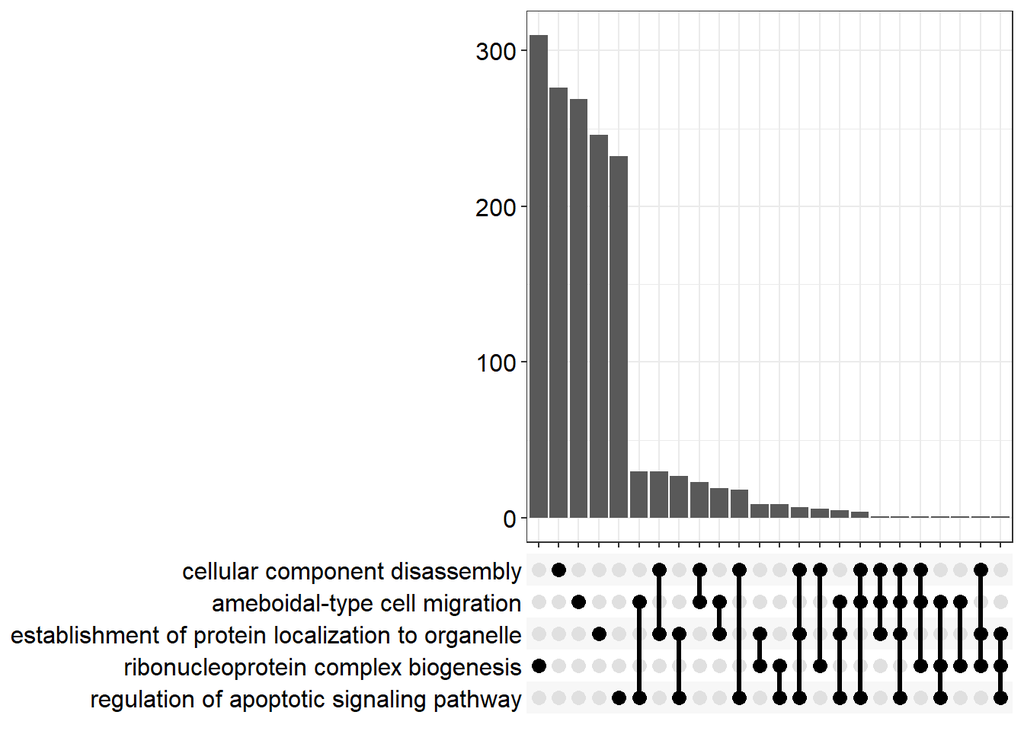

```r
# clusterProfiler has many cool ways to visualise the enrichment analysis results, but the results generally
# would need to be in specific Class object like enrichResult.  upsetplot
upset <- upsetplot(orgdb_result, n = 5)
upset
```

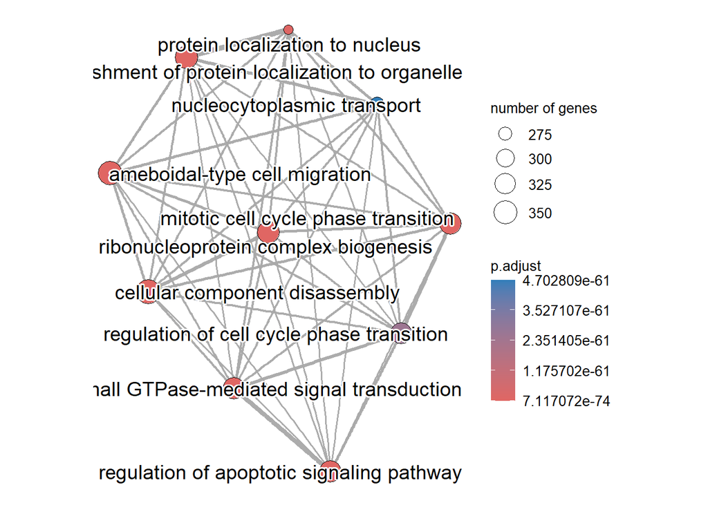

```r
# network plot get semData for the plot
sem_data <- godata("org.Mm.eg.db", ont = "BP", computeIC = TRUE)
p_ema <- emapplot(pairwise_termsim(orgdb_result, method = "Wang", semData = sem_data), showCategory = 10, color = "p.adjust",
    layout.params = list(layout = "nicely"), edge.params = list(min = 0), pie = "Count")
p_ema
```

## 10.4 Manual computation for enrichment analysis

### 10.4.1 Theoretical Basis of Overrepresentation Analysis

The biological question of this report is whether and which gene ontology is overrepresented in the progressor group given the data from the microarray in the source study and the known gene annotations. This might lead to identification of meaningful and perhaps even clinically significant genes and/or biological processes.  
The computation behind enrichment/overrepresentation analysis can be summarised by the following Venn diagram.

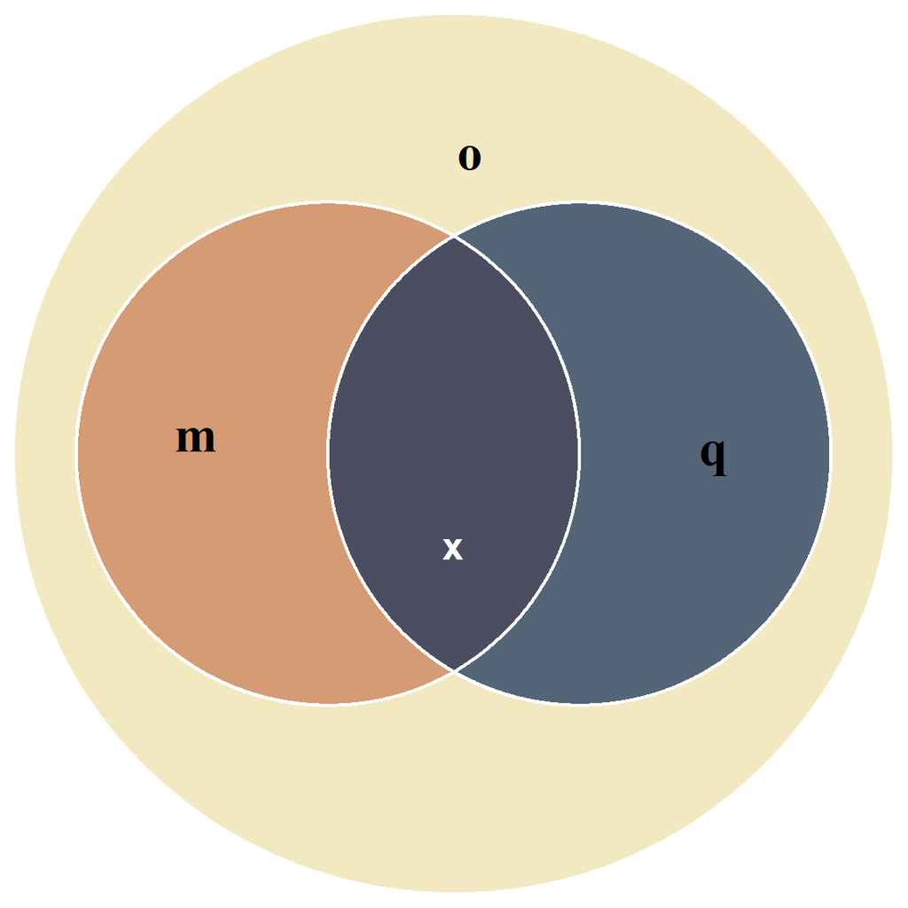

Notation of the Venn diagram:

$\textbf{o}$ = number of probes from the microarray  
$\textbf{m}$ = number of probes from the microarray with known gene ontology (background count)  
$\textbf{q}$ = number of probes in our list of differentially expressed gene (foreground count)  
$\textbf{x}$ ($q \cap m$) = number of differentially expressed gene with the selected gene ontology  
$\textbf{n}$ = number of probes not in our lit of differentially expressed gene  
$\text{Foreground ratio}$ = $\frac{x}{q}$  
$\text{Background ratio}$ = $\frac{m}{o}$

Our biological question above is now transformed into a comparison of whether the $\underline{\text{Foreground ratio}}$ is $\textbf{significantly}$ larger than the $\underline{\text{Background ratio}}$.

Microarray data is huge, especially with 134 samples. Counting and comuting the ratio manually would most certainly be impractical. Instead, we can apply a form of the hypergeometric test/distribution in R.

A story motivation of the hypergeometric distribution can be given as the following: A box contains i pieces of chocolates and j pieces of pickles. Let’s consider getting chocolates are successes and getting pickles are failures. Assuming any object from the box is equally likely go be drawn, the random variable X refers to the number of successes from a draw of n objects from the box without replacement.

In the context of hypergeometric distribution, the question of enrichment analysis is again transformed into the following scenario: We select $\textbf{q}$ probes from the entire microarray $\textbf{o}$, the probability ($\textbf{P}$) of finding $\textbf{x}$ or more probes with differentially expressed gene and gene ontology is given as:

$$P = \sum_{i=x}^{min(q,m)} \binom{q}{x}\binom{o-k}{m-x}$$

Probability Mass Function from other sources may have an additional denominator, namely $\binom{q+o-k}{m}$. This denominator is a scaling term, to ensure that the resulting probability is between 0 and 1. In our enrichment analysis, the goal is compare the relative probabilities among the differential expressed genes. The scaling term can be omitted for such purpose. That said, some packages may implement the algorithm in a more rigorous way, and we could see the scaling denominator in some practices.  
That may be enough theory now. Let’s get into some R-actions.

## 10.5 Define a Function for Computation

At this point, we have both the AGO from the DEG analysis among the various pairs of contrast groups and the GO data from platform on GEO. Instead of using clusterProfiler, we can manually perform the enrichment/overrepresentation analysis. The theoretical section at the beginning requires computation of the background count $\textbf{m}$, the foreground count $\textbf{q}$, the DEGs of selected GO term $\textbf{x}$, and the number of probes without GO terms $\textbf{n}$. An alpha level of 0.05 is chosen. A different alpha level can be chosen based on the tolerance for Type I and II errors.

```r
EACompute <- function(ago, go){
  # assign the arguments.
  AGO <-  ago
  GOdata <- go

  # check the minimal adj.P.Val.
  if (min(AGO$adj.P.Val) < 0.05){
    # perform the EA computation.
    # compute for foreground.
    fg_probe <- rownames(AGO)[which(AGO[, "adj.P.Val"] < 0.05)]
    fg_go_id <- GOdata$Probe_id[GOdata$Probe_id %in% fg_probe]

    # compute for background.
    bg_probe <- rownames(AGO)
    bg_go_id <- GOdata$Probe_id[GOdata$Probe_id %in% bg_probe]

    # compute for the counts for relevant terms form the theoretical section for each gene ontology.
    EA <- data.frame() # enrichment analysis

    # counting for each GO term.
    for (Id in unique(fg_go_id)){
      # total count in background with GO term
      m <- sum(bg_go_id == Id)
      # total count in background without GO term
      n <- length(bg_go_id) - m
      # total count in foreground
      q <- length(fg_go_id)
      # total count in foreground with GO term
      x <- sum(fg_go_id == Id)
      # compute the hypergeometric p-value
      p_val <- phyper(x - 1, m, n, q, lower.tail = FALSE)
      # combine the result for all probes
      EA <- rbind(EA, c(m, m + n, q, x, p_val))
    }
    rownames(EA) = unique(fg_go_id)
    colnames(EA) = c("m", "o(m + n)", "q", "x", "P.Val.hygeo")

    if(nrow(EA) > 0 && any(!is.na(EA[, "x"]))){
      # adjust the P.Val.hygeo for multiple testing across the entire array of probes. Finding true positive is more important to me in this analysis, but use one of the other adjusting methods as needed.
      EA <- cbind(EA, "adj.P.Val.hygeo" = p.adjust(EA[, "P.Val.hygeo"], "BH"))

      # filter again for only the significant results by adj.P.Val.hygeo. We use 0.05 as the alpha level as 0.05 captures only one GO term...
      GOsig <- rownames(EA)[which(EA[, "adj.P.Val.hygeo"] < 0.05)]

      # grab and add GO data.
      GOname <- data.frame(Probe_id = character(), Description = character(), stringsAsFactors = FALSE)

      for (go in GOsig){
        description <- unique(GOdata[which(GOdata[, "Probe_id"] == go), "Description"])
        df <- data.frame(Probe_id = go, Description = description)
        GOname <- rbind(GOname, df)}

      EA <- EA %>%
        rownames_to_column(var = "Probe_id") %>%
        left_join(GOname, by = "Probe_id")

      # we can format the enrichment analysis output as observed and expected, which may be easier to interpret.
      # recall that we want to compare the foreground and background ratios. DEG with the selected gene ontology/foreground count.
      # foreground ratio.
      Ratio_fg <- as.numeric(EA[, "x"])/as.numeric(EA[, "q"])

      # background ratio.
      Ratio_bg <- as.numeric(EA[, "m"])/as.numeric(EA[, "o(m + n)"])

      # expected value of foreground based on the background ratio.
      Ratio_mu_bg <- round(Ratio_bg * as.numeric(EA[, "q"]), 5)

      # create a dataframe as a readable result.
      EA <- data.frame(cbind(`GO id` = EA[, "Probe_id"],
                             Description = EA[, "Description"],
                             `Expected Frequency` = paste0(Ratio_mu_bg, "/", EA[, "q"]),
                             `Observed Frequency` = paste0(EA[, "m"], "/", EA[, "q"]),
                             `Background Ratio` = paste0(EA[, "m"], "/", EA[, "o(m + n)"]),
                             `FoldChange` = Ratio_fg/Ratio_bg, # of GO term.
                             `P.Val` = as.numeric(EA[, "P.Val.hygeo"]),
                             `P.Val.adjusted` = as.numeric(EA[, "adj.P.Val.hygeo"])))

      # add gene information
      tempt <- EA %>%
        left_join(as.data.frame(cbind(probe_id = rownames(GOdata), GOdata)), by = c("GO.id" = "Id"))

      AGO$Probe_id <- as.character(AGO$Probe_id)

      EA_join <- tempt %>%
        left_join(AGO, by = c("GO.id" = "Probe_id"))

      # remove duplicates and unnecessary columns
      EA_join <- select(EA_join, c("probe_id", "GO.id", "Gene_id",
                                   "logFC", "Description.x", "FoldChange",
                                   "P.Val.x", "P.Val.adjusted", "Observed.Frequency", "Background.Ratio"))

      colnames(EA_join) <- c("probe_id", "GO.id", "Gene_id",
                             "logFC", "Description", "FoldChange",
                             "P.Val", "P.Val.adjusted", "Observed.Frequency", "Background.Ratio")

      EA_join <- unique(EA_join)

      # remove duplicate for a clean output table.
      tempt <- EA %>%
        select(c("GO.id", "Description", "Expected.Frequency", "Observed.Frequency",
                 "Background.Ratio", "FoldChange", "P.Val", "P.Val.adjusted"))

      join_list <- EA_join %>%
        select(c("GO.id", "Gene_id"))

      tempt <- tempt %>%
        left_join(join_list, by = "GO.id")

      tempt <- tempt %>%
        group_by(GO.id) %>%
        dplyr::reframe(
          Gene.id = paste(Gene_id, collapse = "/"),
          Description = paste(Description, collapse = "/"))

      # drop the Desirption from EA first (this is inefficient)
      EA <- EA %>% select(-Description)
      EA_tab <- tempt %>%
        left_join(EA, by = "GO.id")

      # remove duplicate gene id and biological pathways
      EA_tab <- EA_tab %>%
        mutate(Gene.id = sapply(Gene.id, function(x) paste(unique(str_split(x, "/")[[1]]), collapse = "/"))) %>%
        mutate(Description = sapply(Description, function(x) paste(unique(str_split(x, "/")[[1]]), collapse = "/"))) %>%
        distinct()

      # create an enrichResult object if you want to use some packages for visualisation.
      # create dataframe for encichResult obj.
      enrich_df <- select(EA_join, c("probe_id", "GO.id", "Description", "Gene_id", "logFC", "P.Val", "P.Val.adjusted"))
      tempt <- GPL16570_lung[, c("probeset_id", "Gene_id")]
      tempt$probe_id <- as.character(rownames(tempt))

      enrich_df <- enrich_df %>%
        left_join(tempt, by = c("GO.id" = "probe_id")) %>%
        select(c("GO.id", "Description", "Gene_id.x", "Gene_id.y", "logFC", "P.Val", "P.Val.adjusted")) %>%
        na.omit()

      # set the column names to avoid confusions.
      colnames(enrich_df) <- c("GO.id", "Description", "AGene.id", "BgGene.id", "logFC", "P.Val", "P.Val.adjusted")

      # count the number of genes and concat the gene id column. The numerator of foreground and background gene ratios are supposed to be the same as we filtered probes by GO terms in earlier sections.
      enrich_df <- enrich_df %>%
        group_by(GO.id, Description, P.Val, P.Val.adjusted) %>%
        dplyr::summarize(
          AGene.id = paste(AGene.id, collapse = "/"),
          AGene.count = sapply(strsplit(AGene.id, "/"), length),
          BgGene.id = paste(BgGene.id, collapse = "/"),
          BgGene.count = sapply(strsplit(BgGene.id, "/"), length))

      array_gene_list <- unique(EA_join$Gene_id)
      gpl_gene_list <- unique(GPL16570_lung$Gene_id)

      # get denominator for computation of gene ratio.
      array_gene_count <- length(unique(EA_join$Gene_id))
      gpl_gene_count <- length(unique(GPL16570_lung$Gene_id))

      # wrangle data into a dataframe with correct format.
      ea_df <- data.frame(cbind(
        ID = enrich_df[, "GO.id"],
        Description = enrich_df[, "Description"],
        GeneRatio = paste0(enrich_df$AGene.count, "/", array_gene_count),
        BgRatio = paste0(enrich_df$BgGene.count, "/", gpl_gene_count),
        pvalue = as.numeric(unlist(enrich_df[, "P.Val"])),
        p.adjust = as.numeric(unlist(enrich_df[, "P.Val.adjusted"])),
        qvalue = rep(0.03, nrow(enrich_df)), # a dummy value for plotting, p.adjust are too small for calculating qvalue.
        geneID = enrich_df[, "AGene.id"],
        Count = enrich_df[, "AGene.count"],
        stringsAsFactors = FALSE))

      # ensure the column ID are exact.
      colnames(ea_df) <- c("ID", "Description", "GeneRatio", "BgRatio", "pvalue", "p.adjust", "qvalue", "geneID", "Count")

      # create a geneset list for mapping GO terms and gene ID.
      geneSets <- setNames(lapply(ea_df$geneID, function(x) unlist(strsplit(x, "/"))), ea_df$ID)

      # create enrichResult object.
      EA_obj <- new("enrichResult",
                    result = ea_df,
                    pvalueCutoff = 0.05,
                    pAdjustMethod = "BH",
                    qvalueCutoff = 0.02,
                    gene = array_gene_list,
                    universe = character(0),
                    gene2Symbol = character(0),
                    geneSets = geneSets,
                    organism = "Mus musculus",
                    keytype = "SYMBOL",
                    ontology = "BP", # biological process
                    readable = TRUE)

      result <- list(EA_tab, EA_obj)
      names(result) <- c("EA_tab", "EA_obj")
      return(result)
    }else print("Not enougn significant GO terms for computation. Increased sample size is required.")
  }else print("GO terms from contrast groups are not significant enough for computation. Set a larger alpha level to proceed.")
}
```

## 10.6 Perform Pairwise Enrichment/Overrepresentation Analysis

```r
EA_ui_ac <- EACompute(Genego_ui_ac$AGO, Genego_ui_ac$GO)
head(EA_ui_ac$EA_tab)

# save the result as a csv file if needed.  write.csv(as.data.frame(EA_ui_ac$EA_tab), 'EA_Fin_ui_ac.csv',
# row.names = FALSE)
## # A tibble: 6 × 9
##   GO.id    Gene.id Description             Expected.Frequency Observed.Frequency
##   <chr>    <chr>   <chr>                   <chr>              <chr>
## 1 17210855 Lypla1  lipid metabolic proces… 23.18989/316609    36/316609
## 2 17210869 Tcea1   transcription, DNA-dep… 27.05487/316609    42/316609
## 3 17210887 Atp6v1h transport/ion transpor… 9.66245/316609     15/316609
## 4 17210912 Rb1cc1  autophagic vacuole ass… 146.86931/316609   228/316609
## 5 17210984 Pcmtd1  cellular protein modif… 9.66245/316609     15/316609
## 6 17211000 Rrs1    NA                      3.86498/316609     6/316609
## # ℹ 4 more variables: Background.Ratio <chr>, FoldChange <chr>, P.Val <chr>,
## #   P.Val.adjusted <chr>
```

```r
EA_ui_cc <- EACompute(Genego_ui_cc$AGO, Genego_ui_cc$GO)
head(EA_ui_cc$EA_tab)
## # A tibble: 6 × 9
##   GO.id    Gene.id       Description       Expected.Frequency Observed.Frequency
##   <chr>    <chr>         <chr>             <chr>              <chr>
## 1 17210855 Lypla1        lipid metabolic … 21.20665/289532    36/289532
## 2 17210869 Tcea1         transcription, D… 24.74109/289532    42/289532
## 3 17210912 Rb1cc1        autophagic vacuo… 134.30877/289532   228/289532
## 4 17210984 Pcmtd1        cellular protein… 8.8361/289532      15/289532
## 5 17211033 1700034P13Rik NA                0.58907/289532     1/289532
## 6 17211090 Cspp1         positive regulat… 24.74109/289532    42/289532
## # ℹ 4 more variables: Background.Ratio <chr>, FoldChange <chr>, P.Val <chr>,
## #   P.Val.adjusted <chr>
```

```r
EA_ui_pr <- EACompute(Genego_ui_pr$AGO, Genego_ui_pr$GO)
head(EA_ui_pr$EA_tab)
## # A tibble: 6 × 9
##   GO.id    Gene.id Description             Expected.Frequency Observed.Frequency
##   <chr>    <chr>   <chr>                   <chr>              <chr>
## 1 17210855 Lypla1  lipid metabolic proces… 27.90384/380968    36/380968
## 2 17210869 Tcea1   transcription, DNA-dep… 32.55448/380968    42/380968
## 3 17210887 Atp6v1h transport/ion transpor… 11.6266/380968     15/380968
## 4 17210912 Rb1cc1  autophagic vacuole ass… 176.72431/380968   228/380968
## 5 17210984 Pcmtd1  cellular protein modif… 11.6266/380968     15/380968
## 6 17211004 Adhfe1  NA                      9.30128/380968     12/380968
## # ℹ 4 more variables: Background.Ratio <chr>, FoldChange <chr>, P.Val <chr>,
## #   P.Val.adjusted <chr>
```

```r
EA_ac_cc <- EACompute(Genego_ac_cc$AGO, Genego_ac_cc$GO)
head(EA_ac_cc$EA_tab)
## # A tibble: 6 × 9
##   GO.id    Gene.id Description             Expected.Frequency Observed.Frequency
##   <chr>    <chr>   <chr>                   <chr>              <chr>
## 1 17211131 Prex2   G-protein coupled rece… 2.70626/110845     12/110845
## 2 17211375 Paqr8   multicellular organism… 5.41253/110845     24/110845
## 3 17211405 Gsta3   metabolic process       1.35313/110845     6/110845
## 4 17211774 Plekhb2 biological_process      1.57865/110845     7/110845
## 5 17211795 Arid5a  chondrocyte differenti… 16.91416/110845    75/110845
## 6 17211832 Cnnm3   transport/ion transpor… 4.0594/110845      18/110845
## # ℹ 4 more variables: Background.Ratio <chr>, FoldChange <chr>, P.Val <chr>,
## #   P.Val.adjusted <chr>
```

```r
EA_ac_pr <- EACompute(Genego_ac_pr$AGO, Genego_ac_pr$GO)
head(EA_ac_pr$EA_tab)
## # A tibble: 6 × 9
##   GO.id    Gene.id       Description       Expected.Frequency Observed.Frequency
##   <chr>    <chr>         <chr>             <chr>              <chr>
## 1 17210855 Lypla1        lipid metabolic … 26.22939/358107    36/358107
## 2 17210869 Tcea1         transcription, D… 30.60096/358107    42/358107
## 3 17210912 Rb1cc1        autophagic vacuo… 166.11949/358107   228/358107
## 4 17210984 Pcmtd1        cellular protein… 10.92891/358107    15/358107
## 5 17211000 Rrs1          NA                4.37157/358107     6/358107
## 6 17211033 1700034P13Rik NA                0.72859/358107     1/358107
## # ℹ 4 more variables: Background.Ratio <chr>, FoldChange <chr>, P.Val <chr>,
## #   P.Val.adjusted <chr>
```

```r
EA_cc_pr <- EACompute(Genego_cc_pr$AGO, Genego_cc_pr$GO)
head(EA_cc_pr$EA_tab)
## # A tibble: 6 × 9
##   GO.id    Gene.id Description             Expected.Frequency Observed.Frequency
##   <chr>    <chr>   <chr>                   <chr>              <chr>
## 1 17210855 Lypla1  lipid metabolic proces… 14.57215/198952    36/198952
## 2 17210869 Tcea1   transcription, DNA-dep… 17.00085/198952    42/198952
## 3 17210887 Atp6v1h transport/ion transpor… 6.07173/198952     15/198952
## 4 17210984 Pcmtd1  cellular protein modif… 6.07173/198952     15/198952
## 5 17211004 Adhfe1  molecular hydrogen tra… 4.85738/198952     12/198952
## 6 17211243 Terf1   telomere maintenance/a… 27.52518/198952    68/198952
## # ℹ 4 more variables: Background.Ratio <chr>, FoldChange <chr>, P.Val <chr>,
## #   P.Val.adjusted <chr>
```

Voilà! Now we have the differentially expressed probes with their gene ontology for biological process from our microarray!

## 10.7 Are Genes Reported in Sources Study Present?

Source study reports on comparison between asymptomatic and other groups, as one of the key finding is that B-cell pathways genes and CD20+ genes are overrepresented in the asymptomatic group. As such, this section will only compare asymtopmatic and any given group.

```r
com_gene_tab_ui_ac <- EA_ui_ac$EA_tab %>%
    filter(str_to_lower(Gene.id) %in% str_to_lower(c("CD79B", "CD79A", "CR2", "FLT3", "BANK1", "PAX5", "MS4A1", "CD19",
        "CD22", "NUP107", "RAE1")))


com_biopath_tab_ui_ac <- EA_ui_ac$EA_tab %>%
    filter(str_detect(Description, regex("B cell activation|B cell differentiation|Lymphocyte differentiation|B cell proliferation|Lymphocyte proliferation|B cell receptor signaling pathway|Regulation of B cell activation|Transcription-dependent tethering of RNA polymerase II gene DNA at nuclear periphery",
        ignore_case = TRUE)))

com_gene_tab_ui_ac
com_biopath_tab_ui_ac
## # A tibble: 2 × 9
##   GO.id    Gene.id Description             Expected.Frequency Observed.Frequency
##   <chr>    <chr>   <chr>                   <chr>              <chr>
## 1 17380185 Rae1    NA                      4.50915/316609     7/316609
## 2 17410581 Bank1   cellular calcium ion h… 6.44164/316609     10/316609
## # ℹ 4 more variables: Background.Ratio <chr>, FoldChange <chr>, P.Val <chr>,
## #   P.Val.adjusted <chr>
## # A tibble: 112 × 9
##    GO.id    Gene.id Description            Expected.Frequency Observed.Frequency
##    <chr>    <chr>   <chr>                  <chr>              <chr>
##  1 17215309 Inpp5d  apoptotic process/neg… 191.96076/316609   298/316609
##  2 17216395 Bcl2    G1/S transition of mi… 214.50649/316609   333/316609
##  3 17218620 Rc3h1   nuclear-transcribed m… 19.32491/316609    30/316609
##  4 17223228 Hspd1   detection of misfolde… 106.287/316609     165/316609
##  5 17224440 Nhej1   DNA repair/double-str… 46.37978/316609    72/316609
##  6 17226043 Bcl2    G1/S transition of mi… 214.50649/316609   333/316609
##  7 17227536 Ptprc   activation of MAPK ac… 202.91154/316609   315/316609
##  8 17229607 Fcgr2b  negative regulation o… 115.94945/316609   180/316609
##  9 17237170 Pawr    transcription, DNA-de… 25.76655/316609    40/316609
## 10 17238482 Rnf41   protein polyubiquitin… 38.64982/316609    60/316609
## # ℹ 102 more rows
## # ℹ 4 more variables: Background.Ratio <chr>, FoldChange <chr>, P.Val <chr>,
## #   P.Val.adjusted <chr>
```

```r
com_gene_tab_ac_cc <- EA_ac_cc$EA_tab %>%
    filter(str_to_lower(Gene.id) %in% str_to_lower(c("CD79B", "CD79A", "CR2", "FLT3", "BANK1", "PAX5", "MS4A1", "CD19",
        "CD22", "NUP107", "RAE1")))

com_biopath_tab_ac_cc <- EA_ac_cc$EA_tab %>%
    filter(str_detect(Description, regex("B cell activation|B cell differentiation|Lymphocyte differentiation|B cell proliferation|Lymphocyte proliferation|B cell receptor signaling pathway|Regulation of B cell activation|Transcription-dependent tethering of RNA polymerase II gene DNA at nuclear periphery",
        ignore_case = TRUE)))

com_gene_tab_ac_cc
com_biopath_tab_ac_cc
## # A tibble: 0 × 9
## # ℹ 9 variables: GO.id <chr>, Gene.id <chr>, Description <chr>,
## #   Expected.Frequency <chr>, Observed.Frequency <chr>, Background.Ratio <chr>,
## #   FoldChange <chr>, P.Val <chr>, P.Val.adjusted <chr>
## # A tibble: 35 × 9
##    GO.id    Gene.id  Description           Expected.Frequency Observed.Frequency
##    <chr>    <chr>    <chr>                 <chr>              <chr>
##  1 17229607 Fcgr2b   negative regulation … 40.59397/110845    180/110845
##  2 17239597 Tnfaip3  B-1 B cell homeostas… 69.00975/110845    306/110845
##  3 17240645 Prdm1    negative regulation … 14.65893/110845    65/110845
##  4 17241962 Mif      prostaglandin biosyn… 23.90534/110845    106/110845
##  5 17280310 Id2      negative regulation … 34.50488/110845    153/110845
##  6 17280729 Ahr      negative regulation … 73.74572/110845    327/110845
##  7 17284354 BC092049 biological_process/a… 11.2761/110845     50/110845
##  8 17284356 AB097847 biological_process/a… 2.93179/110845     13/110845
##  9 17284507 Ighg     biological_process/a… 5.86357/110845     26/110845
## 10 17287381 Syk      activation of MAPK a… 68.55871/110845    304/110845
## # ℹ 25 more rows
## # ℹ 4 more variables: Background.Ratio <chr>, FoldChange <chr>, P.Val <chr>,
## #   P.Val.adjusted <chr>
```

```r
com_gene_tab_ac_pr <- EA_ac_pr$EA_tab %>%
    filter(str_to_lower(Gene.id) %in% str_to_lower(c("CD79B", "CD79A", "CR2", "FLT3", "BANK1", "PAX5", "MS4A1", "CD19",
        "CD22", "NUP107", "RAE1")))

com_biopath_tab_ac_pr <- EA_ac_pr$EA_tab %>%
    filter(str_detect(Description, regex("B cell activation|B cell differentiation|Lymphocyte differentiation|B cell proliferation|Lymphocyte proliferation|B cell receptor signaling pathway|Regulation of B cell activation|Transcription-dependent tethering of RNA polymerase II gene DNA at nuclear periphery",
        ignore_case = TRUE)))

com_gene_tab_ac_pr
com_biopath_tab_ac_pr
## # A tibble: 4 × 9
##   GO.id    Gene.id Description             Expected.Frequency Observed.Frequency
##   <chr>    <chr>   <chr>                   <chr>              <chr>
## 1 17245272 Nup107  mRNA export from nucle… 11.65751/358107    16/358107
## 2 17270837 Cd79b   NA                      5.82875/358107     8/358107
## 3 17380185 Rae1    NA                      5.10016/358107     7/358107
## 4 17410581 Bank1   NA                      7.28594/358107     10/358107
## # ℹ 4 more variables: Background.Ratio <chr>, FoldChange <chr>, P.Val <chr>,
## #   P.Val.adjusted <chr>
## # A tibble: 102 × 9
##    GO.id    Gene.id Description            Expected.Frequency Observed.Frequency
##    <chr>    <chr>   <chr>                  <chr>              <chr>
##  1 17218620 Rc3h1   nuclear-transcribed m… 21.85783/358107    30/358107
##  2 17224440 Nhej1   DNA repair/double-str… 52.45879/358107    72/358107
##  3 17226043 Bcl2    G1/S transition of mi… 242.62189/358107   333/358107
##  4 17229607 Fcgr2b  negative regulation o… 131.14697/358107   180/358107
##  5 17231999 Myb     G1/S transition of mi… 116.57508/358107   160/358107
##  6 17233022 Cd24a   response to hypoxia/c… 157.37636/358107   216/358107
##  7 17238482 Rnf41   protein polyubiquitin… 43.71566/358107    60/358107
##  8 17239597 Tnfaip3 B-1 B cell homeostasi… 222.94985/358107   306/358107
##  9 17239664 Myb     G1/S transition of mi… 102.0032/358107    140/358107
## 10 17241962 Mif     prostaglandin biosynt… 77.23099/358107    106/358107
## # ℹ 92 more rows
## # ℹ 4 more variables: Background.Ratio <chr>, FoldChange <chr>, P.Val <chr>,
## #   P.Val.adjusted <chr>
```

# 11 Conclusions

(1) Source data is non-normal with some outliers, which justifies the use of Mann-Whitney U-test.  
(2) Of the 11 overrepresented genes reported in the asymptomatic group in the source article, 4 are recovered from this project, namely RAE1, BANK1, NUP107, and CD79B.  
(3) Of the 11 overrepresented genes reported in the source article, asymptomatic controller do not show any of the 11 genes when compared to the chronic controller group.  
(4) Many pathways are found to be overrepresented between asymptomatic controller show 249 genes with a wide range of pathways, instead of strict B-cell pathways.

# 12 Final thoughts

(1) The raw CEL files show a high level of correlation even before normalisation, which may suggest the variability between groups is somewhat low. By using rma() in this exploration, source data might have been over,normalisaion, causing the FoldChange computation in the overrepresentation (manual computation) analysis to be identical across all probes in a given pairwise comparison.I attempted downsampling but the issues persist. A better technique with higher sensitivity may be necessary for this source data.  
(2) Some overrepresented genes (e.g., Bank1, Rae1) lack annotations on GPL16570, which might be one of the reasons why the source article uses a custom annotation platform.